[figure not shown]

# Image gradients

Faisal Qureshi  
Professor  
Faculty of Science  
Ontario Tech University  
Oshawa ON Canada  
http://vclab.science.ontariotechu.ca

## Copyright information

© Faisal Qureshi

## License

This work is licensed under a [Creative Commons Attribution-NonCommercial 4.0 International License](http://creativecommons.org/licenses/by-nc/4.0/).

## Outline

- Computing image gradients
- Constructing histogram of oriented gradients
- Comparing histograms

## Task

1. Given an image $I$, compute $\frac{\partial I}{\partial x}$
2. Given an image $I$, compute $\frac{\partial I}{\partial y}$
3. Given an image $I$, compute gradient magnitude and *edge* orientation for each pixel. Recall that edge orientation refers to the normal to the edge passing through a pixel.
4. Color each pixel according to its edge orientation.
5. Construct gradient magnitude histogram for pixels with non-zero gradient magnitude. Use 32 bins.
6. Construct gradient orientation histogram for pixels with non-zero gradient magnitude. Use 360 bins. We assume that gradient orientations vary between -180 and +180 (in degrees).
7. For a given image $I$ and its rotated version $I_\mathrm{rot}$, show that their gradient magnitude histogram stays the same, but that their gradient angle histogram changes. Implement a method that returns True if the two histograms are the same, False otherwise.

## Starter code

```python
import cv2 as cv
import numpy as np
import scipy as sp
from scipy import signal
import matplotlib.pyplot as plt
import matplotlib.cm as cm
```

### A toy image

White square over a black background

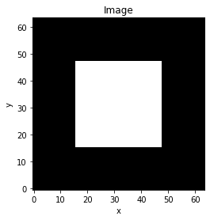

```python
img = np.zeros((64,64))
img[16:48, 16:48] = np.ones((32,32))

plt.title('Image')
plt.ylabel('y')
plt.xlabel('x')
plt.imshow(img, origin='lower', cmap='gray');
```

### Image derivatives

```python
# %load solutions/04-image-gradients/image-deriv.py
```

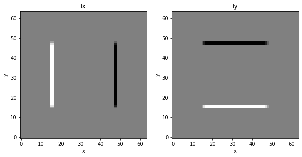

```python
plt.figure(figsize=(10,5))
plt.subplot(121)
plt.title('Ix')
plt.xlabel('x'), plt.ylabel('y')
plt.imshow(Ix, origin='lower', cmap='gray')
plt.subplot(122)
plt.title('Iy')
plt.xlabel('x'), plt.ylabel('y')
plt.imshow(Iy,origin='lower',cmap='gray');
```

### Visualizing gradient magnitude and direction using colors

```python
# %load solutions/04-image-gradients/image-grad.py
```

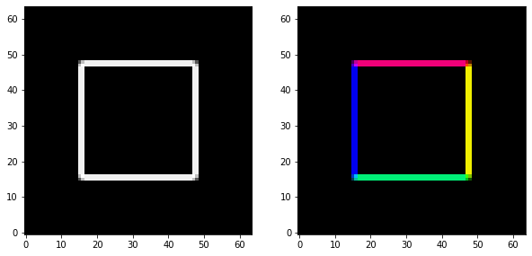

```python
plt.figure(figsize=(10,5))
plt.subplot(121)
plt.imshow(Igrad, origin='lower', cmap='gray')
plt.subplot(122)
plt.imshow(Igrad_color, origin='lower', cmap=cm.get_cmap('prism'));
```

### Histogram of gradient magnitudes and gradient orientations

```python
# %load solutions/04-image-gradients/compute_histograms.py
```

```python
# IMPLEMENT compute_histograms method
```

[figure not shown]

```python
h_grad1, c_grad1, h_angle1, c_angle1 = compute_histograms(img)
h_angle1 = h_angle1 / np.sum(h_angle1)
plt.figure(figsize=(15,3))
plt.subplot(131)
plt.imshow(img, cmap='gray')
plt.subplot(132)
plt.title('Gradient magnitude histogram')
plt.bar(c_grad1, h_grad1, width=10000)
plt.subplot(133)
plt.title('Gradient angle histogram')
plt.bar(c_angle1, h_angle1, width=10);
```

### The effect of image rotation on gradient magnitudes and gradient orientations

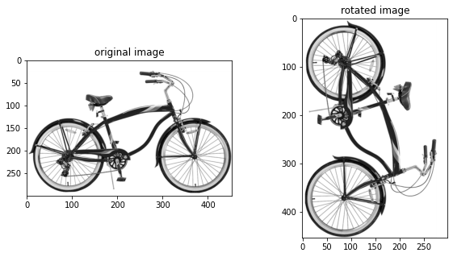

```python
img = cv.imread('data/bicycle.bmp', 0)
img_rot = cv.rotate(img, cv.ROTATE_90_CLOCKWISE)

plt.figure(figsize=(10,5))
plt.subplot(121)
plt.title('original image')
plt.imshow(img, cmap='gray')
plt.subplot(122)
plt.title('rotated image')
plt.imshow(img_rot, cmap='gray');
```

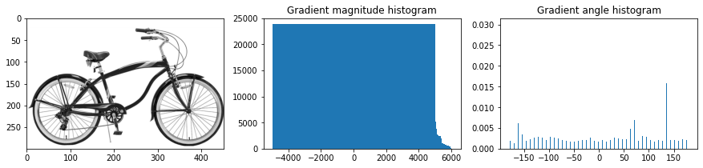

```python
h_grad1, c_grad1, h_angle1, c_angle1 = compute_histograms(img)
h_angle1 = h_angle1 / np.sum(h_angle1)
plt.figure(figsize=(15,3))
plt.subplot(131)
plt.imshow(img, cmap='gray')
plt.subplot(132)
plt.title('Gradient magnitude histogram')
plt.bar(c_grad1, h_grad1, width=10000)
plt.subplot(133)
plt.title('Gradient angle histogram')
plt.bar(c_angle1, h_angle1, width=0.1);
```

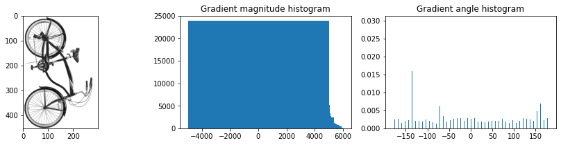

```python
h_grad2, c_grad2, h_angle2, c_angle2 = compute_histograms(img_rot)
h_angle2 = h_angle2 / np.sum(h_angle2)
plt.figure(figsize=(15,3))
plt.subplot(131)
plt.imshow(img_rot, cmap='gray')
plt.subplot(132)
plt.title('Gradient magnitude histogram')
plt.bar(c_grad2, h_grad2, width=10000)
plt.subplot(133)
plt.title('Gradient angle histogram')
plt.bar(c_angle2, h_angle2, width=0.1);
```

```python
# %load solutions/04-image-gradients/compare_histograms.py
```

```python
print(f'Gradient magnitude historams are the same: {compare_histograms(h_grad1, h_grad2)}')
print(f'Gradient angle historams are the same: {compare_histograms(h_angle1, h_angle2)}')
```

```
Gradient magnitude historams are the same: True
Gradient angle historams are the same: False
```

## Submission

[figure not shown]